# Tarea: Modelización de datos de entrada

25 de enero de 2019

## Modelización de datos de Precipitación

La siguiente práctica consiste en determinar la distribución de la cantidad de precipitación diaria en una localidad geográfica. los datos de este ejercicio corresponden a la localidad de Gavidia, en el páramo merideño durante los años 2000 a 2004 para el mes de octubre.

```r
datos <-load("PreMensual.RData")
```

Seleccionamos los datos del mes de octubre:

```r
oct_d <- byMonth %>%
    filter(M==10)
head(oct_d)
```

```
## # A tibble: 6 x 2
## # Groups:   M [1]
##       M     P
##   <int> <dbl>
## 1    10     5
## 2    10     1
## 3    10    27
## 4    10    14
## 5    10     1
## 6    10     1
```

Tomamos solo la variable de precipitación:

```r
octubre <- oct_d$P
head(octubre)
```

```
## [1]  5  1 27 14  1  1
```

## Independencia de los datos

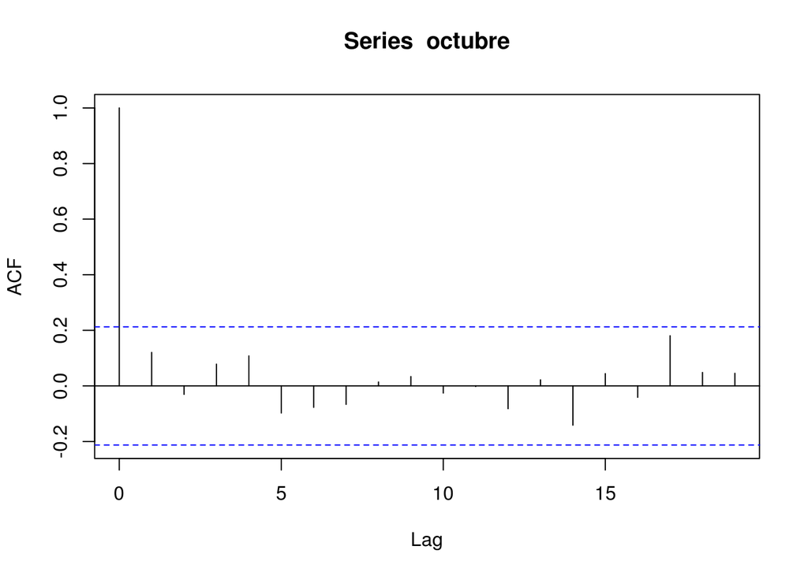

```r
n= length(octubre)

acf(octubre)
```

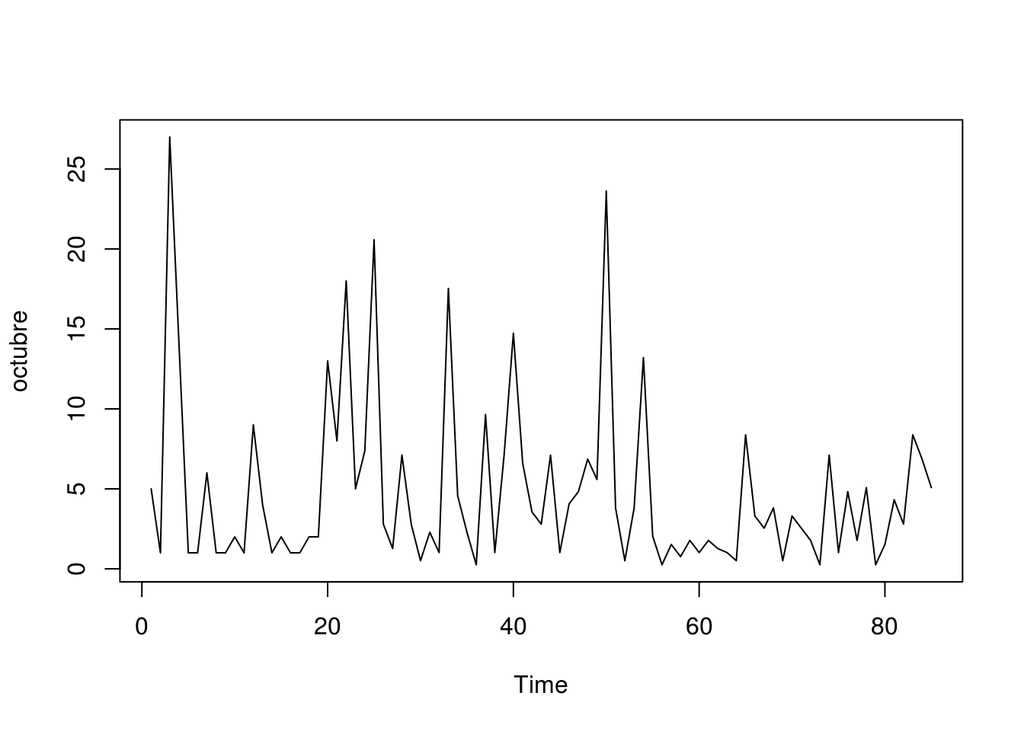

```r
ts.plot(octubre)
```

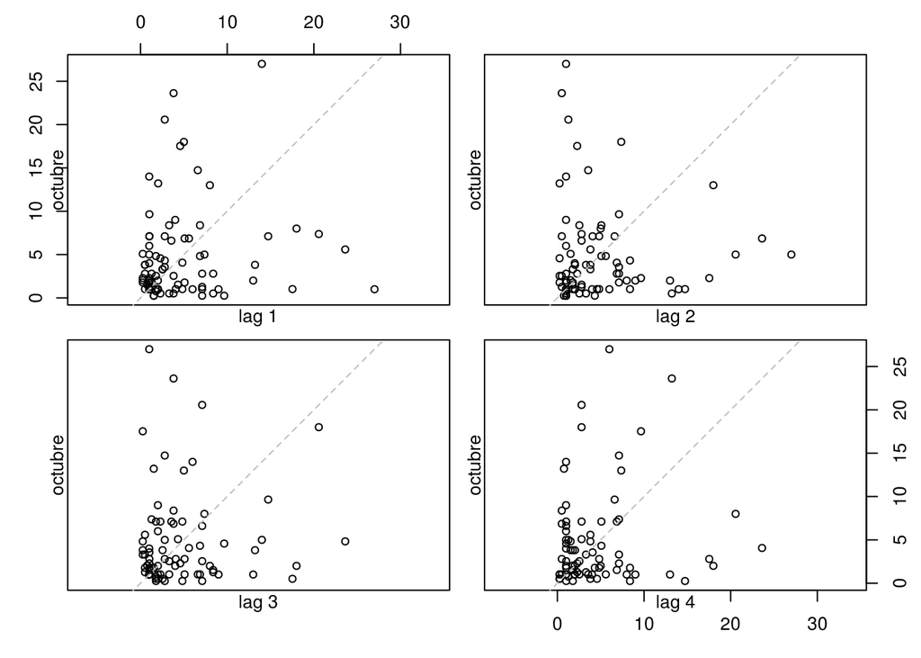

```r
lag.plot(octubre,lags=4,layout=c(2,2),labels=F,do.lines=F)
```

Se concluye que los datos son independientes

## Formulación de hipótesis

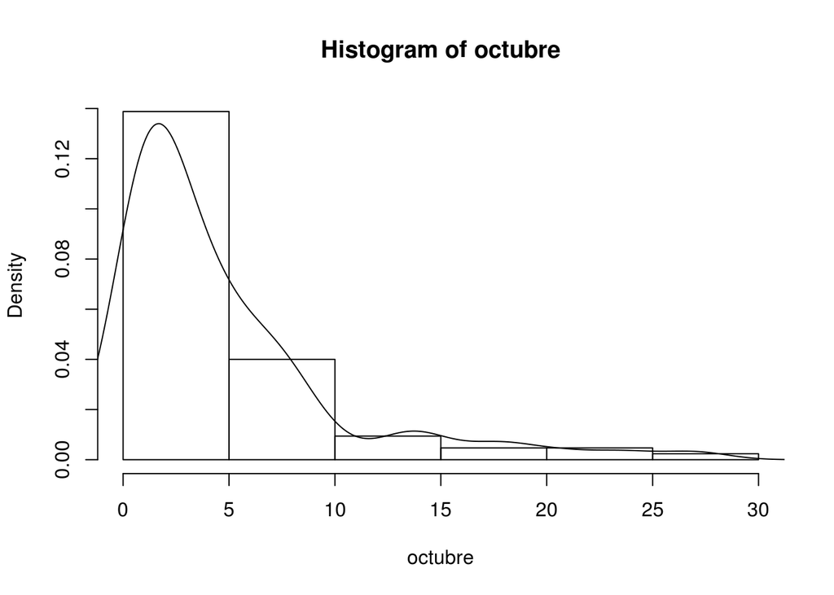

```r
hist(octubre,prob=T)

lines(density(octubre))
```

```r
summary(octubre)
```

```
##    Min. 1st Qu.  Median    Mean 3rd Qu.    Max.
##   0.254   1.016   2.794   4.748   6.604  27.000
```

```r
var(octubre)
```

```
## [1] 28.95085
```

```r
cvar = sd(octubre)/mean(octubre)
cvar
```

```
## [1] 1.133151
```

```r
sd(octubre)
```

```
## [1] 5.3806
```

Gráfico de Caja:

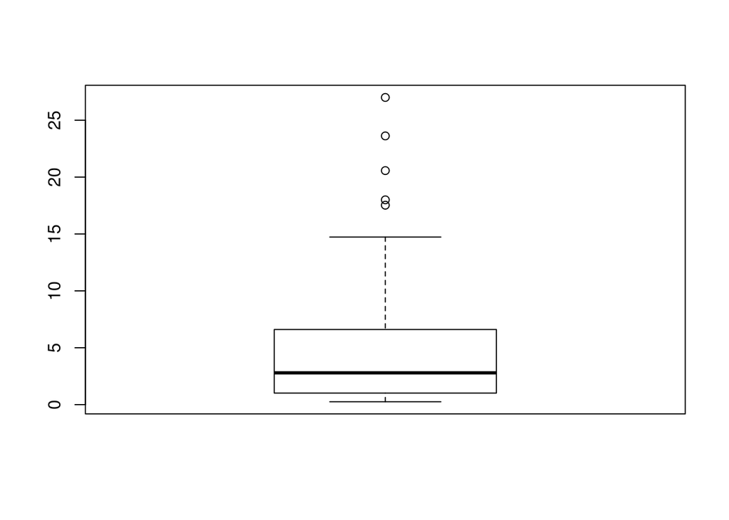

```r
boxplot(octubre)
```

## Estimación de los parámetros de las tres distribuciones y Evaluación del Ajuste:

- Prueba Chi-Cuadrado

Comparamos las gráficas de las funciones de probabilidad acumulada de las tres distribuciones con la función de probabilidad empírica de los datos

```r
library(MASS)
n2mfrow=3
lnorm.par = fitdistr(octubre, "lognormal")
lnorm.par
```

```
##     meanlog       sdlog
##   1.00028979   1.10276066
##  (0.11961119) (0.08457788)
```

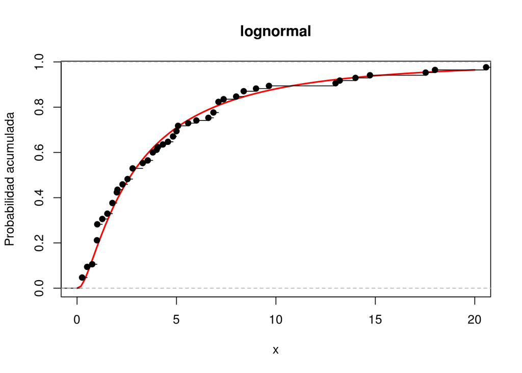

```r
curve(plnorm(x,meanlog=lnorm.par$estimate[1],sdlog=lnorm.par$estimate[2]),from=0, to=20,ylab="Probabilidad acumulada",col="red",lwd=2, main="lognormal")
lines(ecdf(octubre))
```

```r
weib.par =fitdistr(octubre,"weibull")
weib.par
```

```
##      shape        scale
##   0.97523911   4.69316225
##  (0.07909235) (0.55317283)
```

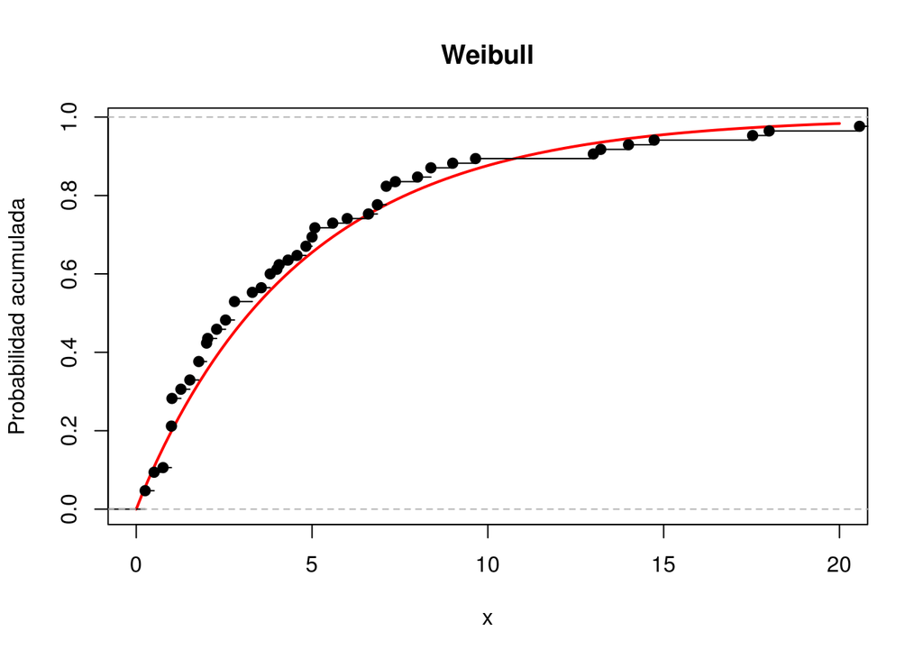

```r
curve(pweibull(x,shape=weib.par$estimate[1],scale=weib.par$estimate[2]),from=0, to=20,ylab="Probabilidad acumulada",col="red",lwd=2, main="Weibull")
lines(ecdf(octubre))
```

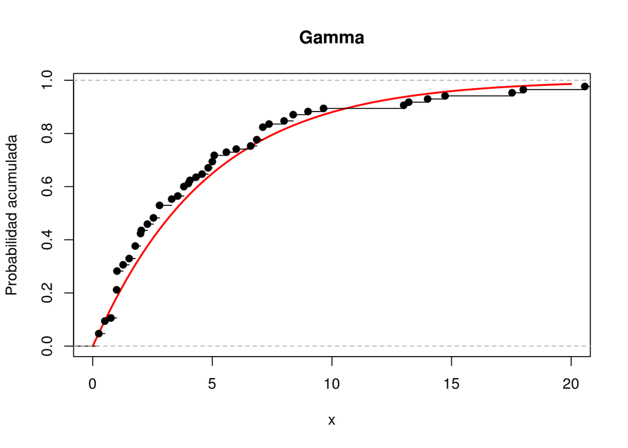

```r
gamma.par =fitdistr(octubre,"gamma")
curve(pgamma(x,shape=gamma.par$estimate[1],rate=gamma.par$estimate[2]),from=0, to=20,ylab="Probabilidad acumulada",col="red",lwd=2, main="Gamma")
lines(ecdf(octubre))
```

Las tres gráficas son muy similares. Ahora los hacemos con la gráfica cuantil-cuantil:

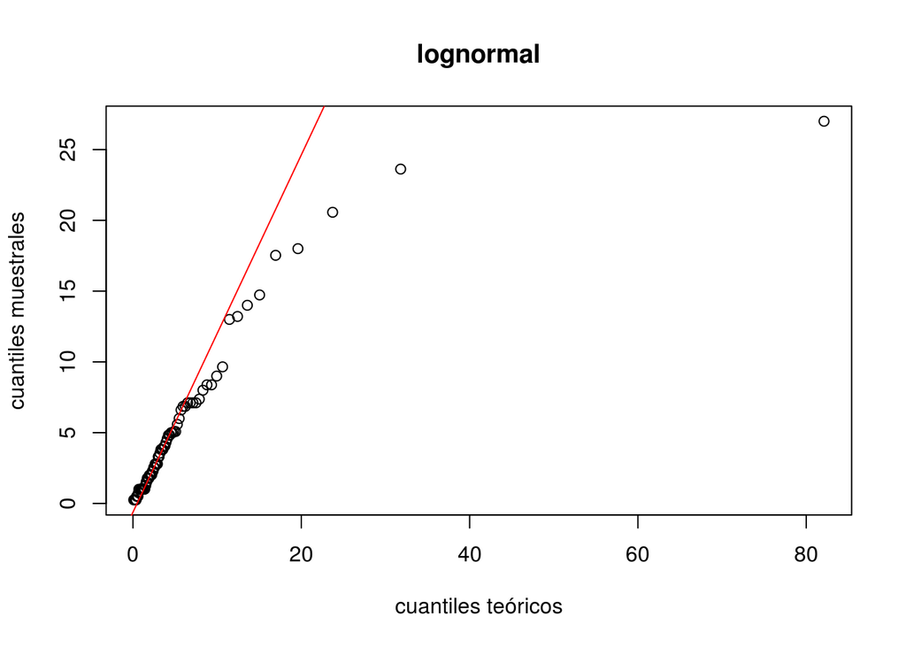

```r
n2mfrow=3
qqplot(qlnorm(ppoints(500), meanlog=lnorm.par$estimate[1],sdlog=lnorm.par$estimate[2]), octubre, main ="lognormal",xlab="cuantiles teóricos",ylab="cuantiles muestrales" )
qqline(octubre, distribution = function(p)
qlnorm(p, meanlog=lnorm.par$estimate[1],sdlog=lnorm.par$estimate[2]),prob = c(0.25, 0.75), col = 2)
```

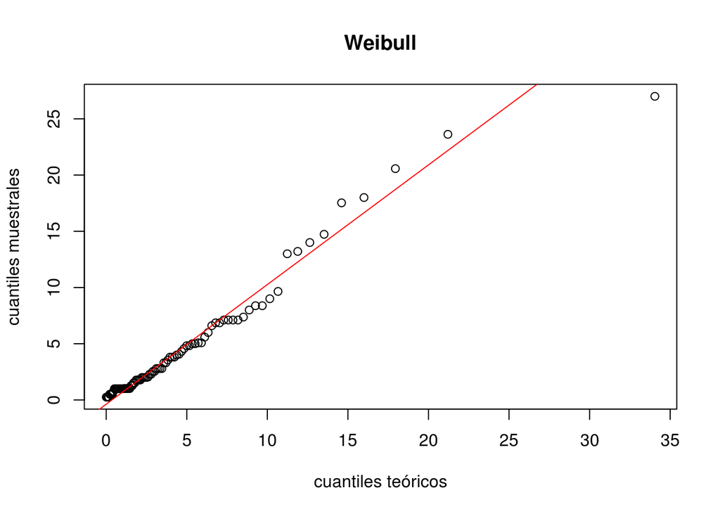

```r
qqplot(qweibull(ppoints(500), shape=weib.par$estimate[1],scale=weib.par$estimate[2]), octubre, main ="Weibull",xlab="cuantiles teóricos",ylab="cuantiles muestrales" )
qqline(octubre, distribution = function(p)
  qweibull(p, shape=weib.par$estimate[1],scale=weib.par$estimate[2]),prob = c(0.25, 0.75), col = 2)
```

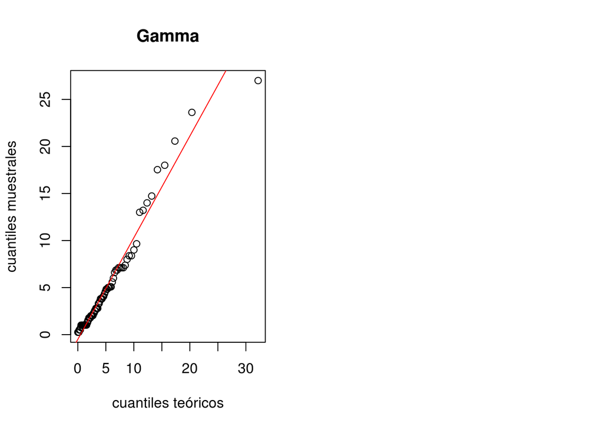

```r
par(mfrow=c(1,2))
qqplot(qgamma(ppoints(500), shape=gamma.par$estimate[1],rate=gamma.par$estimate[2]), octubre, main ="Gamma",xlab="cuantiles teóricos",ylab="cuantiles muestrales" )
qqline(octubre, distribution = function(p)
  qgamma(p, shape=gamma.par$estimate[1],rate=gamma.par$estimate[2]),prob = c(0.25, 0.75), col = 2)
```

Pruebas de gráficos de caja:

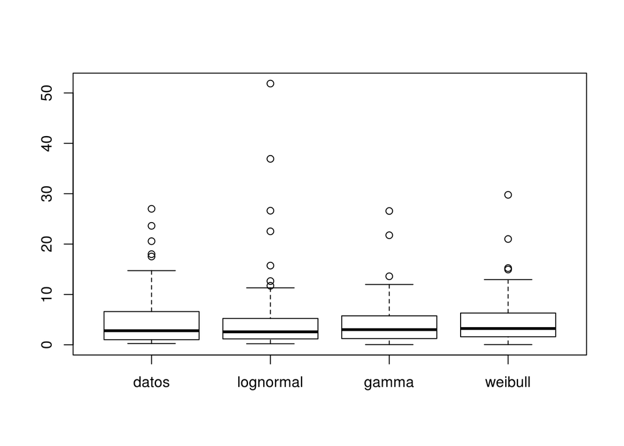

```r
n2mfrow=c(1,1,1)

s.lnorm=rlnorm(n,meanlog=lnorm.par$estimate[1],sdlog=lnorm.par$estimate[2])
s.gamma=rgamma(n,shape=gamma.par$estimate[1],rate=gamma.par$estimate[2])
s.weibull=rweibull(n,shape=weib.par$estimate[1],scale=weib.par$estimate[2])
boxplot(octubre,s.lnorm,s.gamma,s.weibull,names=c("datos","lognormal","gamma","weibull"))
```

*Prueba Chi-Cuadrada:

```r
hist(octubre,plot=F)
```

```
## $breaks
## [1]  0  5 10 15 20 25 30
##
## $counts
## [1] 59 17  4  2  2  1
##
## $density
## [1] 0.138823529 0.040000000 0.009411765 0.004705882 0.004705882 0.002352941
##
## $mids
## [1]  2.5  7.5 12.5 17.5 22.5 27.5
##
## $xname
## [1] "octubre"
##
## $equidist
## [1] TRUE
##
## attr(,"class")
## [1] "histogram"
```

```r
limites = c(0,2,4,6,18)
k = 4
observadas = table(cut(octubre,limites))
observadas
```

```
##
##  (0,2]  (2,4]  (4,6] (6,18]
##     36     16     11     19
```

Calculamos las esperadas:

```r
p.lnorm = numeric(k)
for (i in 1:k) {
  p.lnorm[i] = plnorm(limites[i+1],meanlog=lnorm.par$estimate[1],sdlog=lnorm.par$estimate[2])-plnorm(limites[i],meanlog=lnorm.par$estimate[1],sdlog=lnorm.par$estimate[2])
}
espera.lnorm = n*p.lnorm
X2lnorm = sum((observadas - espera.lnorm)^2/espera.lnorm)
X2lnorm
```

```
## [1] 1.822077
```

```r
p.wei = numeric(k)
for (i in 1:k) {
  p.wei[i] = pweibull(limites[i+1],shape=weib.par$estimate[1],scale=weib.par$estimate[2])-pweibull(limites[i],shape=weib.par$estimate[1],scale=weib.par$estimate[2])
}
espera.wei = n*p.wei
X2wei = sum((observadas - espera.wei)^2/espera.wei)
X2wei
```

```
## [1] 2.125564
```

```r
p.gam = numeric(k)
for (i in 1:k) {
  p.gam[i] = pgamma(limites[i+1],shape=gamma.par$estimate[1],rate=gamma.par$estimate[2])-pgamma(limites[i],shape=gamma.par$estimate[1],rate=gamma.par$estimate[2])
}
espera.gam = n*p.gam
X2gam = sum((observadas - espera.gam)^2/espera.gam)
X2gam
```

```
## [1] 3.204768
```

Comparamos con el estadistico:

Calculamos el estadístico:

```r
alfa = 0.1
n.param = 2
gl = length(observadas) - n.param - 1
X2crit =qchisq(1-alfa,gl)
X2crit
```

```
## [1] 2.705543
```

Como X2crit < X2gam. Rechamos H0 para la gamma.

Prueba Kolmogorov-Smirnof:

Calculamos la función de probabilidad empírica de los datos

```r
Fn = (1:n)/n
Fn
```

```
##  [1] 0.01176471 0.02352941 0.03529412 0.04705882 0.05882353 0.07058824
##  [7] 0.08235294 0.09411765 0.10588235 0.11764706 0.12941176 0.14117647
## [13] 0.15294118 0.16470588 0.17647059 0.18823529 0.20000000 0.21176471
## [19] 0.22352941 0.23529412 0.24705882 0.25882353 0.27058824 0.28235294
## [25] 0.29411765 0.30588235 0.31764706 0.32941176 0.34117647 0.35294118
## [31] 0.36470588 0.37647059 0.38823529 0.40000000 0.41176471 0.42352941
## [37] 0.43529412 0.44705882 0.45882353 0.47058824 0.48235294 0.49411765
## [43] 0.50588235 0.51764706 0.52941176 0.54117647 0.55294118 0.56470588
## [49] 0.57647059 0.58823529 0.60000000 0.61176471 0.62352941 0.63529412
## [55] 0.64705882 0.65882353 0.67058824 0.68235294 0.69411765 0.70588235
## [61] 0.71764706 0.72941176 0.74117647 0.75294118 0.76470588 0.77647059
## [67] 0.78823529 0.80000000 0.81176471 0.82352941 0.83529412 0.84705882
## [73] 0.85882353 0.87058824 0.88235294 0.89411765 0.90588235 0.91764706
## [79] 0.92941176 0.94117647 0.95294118 0.96470588 0.97647059 0.98823529
## [85] 1.00000000
```

```r
Fnm = c(0,Fn[1:(n-1)])
Fnm
```

```
##  [1] 0.00000000 0.01176471 0.02352941 0.03529412 0.04705882 0.05882353
##  [7] 0.07058824 0.08235294 0.09411765 0.10588235 0.11764706 0.12941176
## [13] 0.14117647 0.15294118 0.16470588 0.17647059 0.18823529 0.20000000
## [19] 0.21176471 0.22352941 0.23529412 0.24705882 0.25882353 0.27058824
## [25] 0.28235294 0.29411765 0.30588235 0.31764706 0.32941176 0.34117647
## [31] 0.35294118 0.36470588 0.37647059 0.38823529 0.40000000 0.41176471
## [37] 0.42352941 0.43529412 0.44705882 0.45882353 0.47058824 0.48235294
## [43] 0.49411765 0.50588235 0.51764706 0.52941176 0.54117647 0.55294118
## [49] 0.56470588 0.57647059 0.58823529 0.60000000 0.61176471 0.62352941
## [55] 0.63529412 0.64705882 0.65882353 0.67058824 0.68235294 0.69411765
## [61] 0.70588235 0.71764706 0.72941176 0.74117647 0.75294118 0.76470588
## [67] 0.77647059 0.78823529 0.80000000 0.81176471 0.82352941 0.83529412
## [73] 0.84705882 0.85882353 0.87058824 0.88235294 0.89411765 0.90588235
## [79] 0.91764706 0.92941176 0.94117647 0.95294118 0.96470588 0.97647059
## [85] 0.98823529
```

Ordenamos los datos

```r
ord = sort(octubre)
ord
```

```
##  [1]  0.254  0.254  0.254  0.254  0.508  0.508  0.508  0.508  0.762  1.000
## [11]  1.000  1.000  1.000  1.000  1.000  1.000  1.000  1.000  1.016  1.016
## [21]  1.016  1.016  1.016  1.016  1.270  1.270  1.524  1.524  1.778  1.778
## [31]  1.778  1.778  2.000  2.000  2.000  2.000  2.032  2.286  2.286  2.540
## [41]  2.540  2.794  2.794  2.794  2.794  3.302  3.302  3.556  3.810  3.810
## [51]  3.810  4.000  4.064  4.318  4.572  4.826  4.826  5.000  5.000  5.080
## [61]  5.080  5.588  6.000  6.604  6.858  6.858  7.110  7.110  7.110  7.110
## [71]  7.370  8.000  8.380  8.380  9.000  9.650 13.000 13.210 14.000 14.730
## [81] 17.530 18.000 20.570 23.620 27.000
```

Prueba K-S:

Calculamos las funciones acumuladas

```r
Fhatg = pgamma(ord,shape=gamma.par$estimate[1],rate=gamma.par$estimate[2])

Fhatl = plnorm(ord, meanlog= lnorm.par$estimate[1], sdlog=lnorm.par$estimate[2])


Fhatw = pweibull(ord, shape = weib.par$estimate[1], scale=weib.par$estimate[2])
```

Calculamos de Dn+ y hallamos el máximo

```r
Dnposg = Fn - Fhatg
Dnposg
```

```
##  [1] -0.036561227 -0.024796521 -0.013031815 -0.001267110 -0.037261583
##  [6] -0.025496877 -0.013732171 -0.001967465 -0.036148102 -0.065621108
## [11] -0.053856403 -0.042091697 -0.030326991 -0.018562285 -0.006797579
## [16]  0.004967127  0.016731833  0.028496539  0.037552915  0.049317620
## [21]  0.061082326  0.072847032  0.084611738  0.096376444  0.066222411
## [26]  0.077987117  0.049831312  0.061596018  0.035383678  0.047148384
## [31]  0.058913090  0.070677796  0.050788981  0.062553687  0.074318393
## [36]  0.086083099  0.093400477  0.070867263  0.082631968  0.061825954
## [41]  0.073590660  0.054435720  0.066200426  0.077965132  0.089729838
## [46]  0.044308978  0.056073684  0.041427250  0.028142219  0.039906925
## [51]  0.051671631  0.045548425  0.051446094  0.040686666  0.031096751
## [56]  0.022617705  0.034382411  0.032891453  0.044656159  0.050487622
## [61]  0.062252328  0.038592410  0.024295094  0.001740911  0.000337552
## [66]  0.012102258  0.011486791  0.023251497  0.035016203  0.046780909
## [71]  0.046449488  0.031538274  0.028862187  0.040626893  0.031205997
## [76]  0.023577052 -0.031137662 -0.022157436 -0.019811245 -0.015436747
## [81] -0.023336352 -0.013859152 -0.011220572 -0.005394983  0.003068119
```

```r
Dn.plusg = max(Dnposg)
Dn.plusg
```

```
## [1] 0.09637644
```

```r
Dnposl = Fn - Fhatl
Dnposl
```

```
##  [1] -0.004020959  0.007743747  0.019508453  0.031273158 -0.005276282
##  [6]  0.006488424  0.018253130  0.030017836 -0.018458336 -0.064535751
## [11] -0.052771045 -0.041006340 -0.029241634 -0.017476928 -0.005712222
## [16]  0.006052484  0.017817190  0.029581896  0.037516115  0.049280821
## [21]  0.061045526  0.072810232  0.084574938  0.096339644  0.049125480
## [26]  0.060890185  0.017856090  0.029620796 -0.008862357  0.002902349
## [31]  0.014667054  0.026431760 -0.002070717  0.009693989  0.021458695
## [36]  0.033223401  0.039453227  0.009562466  0.021327171 -0.004781806
## [41]  0.006982900 -0.015715797 -0.003951091  0.007813615  0.019578321
## [46] -0.028730942 -0.016966236 -0.031423369 -0.043690713 -0.031926008
## [51] -0.020161302 -0.025078990 -0.018701730 -0.027245533 -0.034205209
## [56] -0.039737153 -0.027972447 -0.027304654 -0.015539948 -0.008685441
## [61]  0.003079265 -0.013777010 -0.022357518 -0.036560903 -0.034536528
## [66] -0.022771823 -0.020062836 -0.008298130  0.003466576  0.015231282
## [71]  0.018235980  0.010949858  0.012528206  0.024292912  0.021225537
## [76]  0.019471163 -0.016147275 -0.006479503 -0.001956493  0.003918994
## [81] -0.001541236  0.007974393  0.009724905  0.013212363  0.018687833
```

```r
Dn.plusl = max(Dnposl)
Dn.plusl
```

```
## [1] 0.09633964
```

```r
Dnposw = Fn - Fhatw
Dnposw
```

```
##  [1] -0.0447498000 -0.0329850941 -0.0212203883 -0.0094556824 -0.0492474584
##  [6] -0.0374827525 -0.0257180466 -0.0139533407 -0.0503173081 -0.0809498980
## [11] -0.0691851921 -0.0574204862 -0.0456557803 -0.0338910744 -0.0221263686
## [16] -0.0103616627  0.0014030432  0.0131677491  0.0221692873  0.0339339932
## [21]  0.0456986990  0.0574634049  0.0692281108  0.0809928167  0.0502734602
## [26]  0.0620381661  0.0337734440  0.0455381498  0.0195451633  0.0313098692
## [31]  0.0430745751  0.0548392810  0.0353394867  0.0471041926  0.0588688985
## [36]  0.0706336044  0.0780192307  0.0561150294  0.0678797353  0.0478247715
## [41]  0.0595894774  0.0412696320  0.0530343379  0.0647990438  0.0765637497
## [46]  0.0329542011  0.0447189070  0.0310079245  0.0186582636  0.0304229695
## [51]  0.0421876754  0.0367574754  0.0428865251  0.0330320568  0.0243212038
## [56]  0.0166904461  0.0284551520  0.0275256475  0.0392903534  0.0453742938
## [61]  0.0571389997  0.0349945807  0.0218107425  0.0006992106 -0.0001636553
## [66]  0.0116010506  0.0114842953  0.0232490011  0.0350137070  0.0467784129
## [71]  0.0469234939  0.0330148993  0.0308464157  0.0426111215  0.0338765189
## [76]  0.0267986042 -0.0269780762 -0.0180097468 -0.0157527032 -0.0115103828
## [81] -0.0201501832 -0.0108118779 -0.0089113666 -0.0038215820  0.0040496590
```

```r
Dn.plusw = max(Dnposw)
Dn.plusw
```

```
## [1] 0.08099282
```

Calculamos Dn- y hallamos el máximo

```r
Dnnegg = Fhatg -Fnm
Dnnegg
```

```
##  [1]  0.0483259331  0.0365612272  0.0247965214  0.0130318155  0.0490262884
##  [6]  0.0372615825  0.0254968766  0.0137321707  0.0479128074  0.0773858144
## [11]  0.0656211085  0.0538564026  0.0420916967  0.0303269908  0.0185622849
## [16]  0.0067975791 -0.0049671268 -0.0167318327 -0.0257882086 -0.0375529145
## [21] -0.0493176204 -0.0610823263 -0.0728470322 -0.0846117381 -0.0544577050
## [26] -0.0662224109 -0.0380666063 -0.0498313122 -0.0236189724 -0.0353836783
## [31] -0.0471483842 -0.0589130901 -0.0390242751 -0.0507889809 -0.0625536868
## [36] -0.0743183927 -0.0816357711 -0.0591025566 -0.0708672625 -0.0500612484
## [41] -0.0618259543 -0.0426710140 -0.0544357199 -0.0662004258 -0.0779651316
## [46] -0.0325442723 -0.0443089782 -0.0296625445 -0.0163775136 -0.0281422195
## [51] -0.0399069254 -0.0337837189 -0.0396813882 -0.0289219603 -0.0193320451
## [56] -0.0108529989 -0.0226177048 -0.0211267472 -0.0328914531 -0.0387229163
## [61] -0.0504876222 -0.0268277040 -0.0125303877  0.0100237953  0.0114271538
## [66] -0.0003375520  0.0002779147 -0.0114867912 -0.0232514971 -0.0350162029
## [71] -0.0346847819 -0.0197735683 -0.0170974814 -0.0288621872 -0.0194412906
## [76] -0.0118123460  0.0429023680  0.0339221422  0.0315759509  0.0272014531
## [81]  0.0351010576  0.0256238576  0.0229852779  0.0171596893  0.0086965867
```

```r
Dn.minusg =  max(Dnnegg)
Dn.minusg
```

```
## [1] 0.07738581
```

```r
Dnnegl = Fhatl - Fnm
Dnnegl
```

```
##  [1]  0.0157856651  0.0040209592 -0.0077437466 -0.0195084525  0.0170409878
##  [6]  0.0052762819 -0.0064884240 -0.0182531299  0.0302230416  0.0763004572
## [11]  0.0645357513  0.0527710454  0.0410063395  0.0292416336  0.0174769277
## [16]  0.0057122219 -0.0060524840 -0.0178171899 -0.0257514088 -0.0375161147
## [21] -0.0492808206 -0.0610455265 -0.0728102323 -0.0845749382 -0.0373607737
## [26] -0.0491254796 -0.0060913839 -0.0178560898  0.0206270633  0.0088623574
## [31] -0.0029023485 -0.0146670544  0.0138354230  0.0020707171 -0.0096939888
## [36] -0.0214586947 -0.0276885210  0.0022022403 -0.0095624656  0.0165465120
## [41]  0.0047818061  0.0274805028  0.0157157969  0.0039510910 -0.0078136148
## [46]  0.0404956475  0.0287309416  0.0431880751  0.0554554194  0.0436907135
## [51]  0.0319260076  0.0368436957  0.0304664359  0.0390102388  0.0459699145
## [56]  0.0515018586  0.0397371527  0.0390693595  0.0273046536  0.0204501467
## [61]  0.0086854408  0.0255417160  0.0341222241  0.0483256087  0.0463012343
## [66]  0.0345365284  0.0318275417  0.0200628358  0.0082981299 -0.0034665760
## [71] -0.0064712744  0.0008148480 -0.0007635003 -0.0125282062 -0.0094608307
## [76] -0.0077064572  0.0279119813  0.0182442089  0.0137211985  0.0078457121
## [81]  0.0133059421  0.0037903125  0.0020398011 -0.0014476574 -0.0069231272
```

```r
Dn.minusl = max(Dnnegl)
Dn.minusl
```

```
## [1] 0.07630046
```

```r
Dnnegw = Fhatw - Fnm
Dnnegw
```

```
##  [1]  0.0565145059  0.0447498000  0.0329850941  0.0212203883  0.0610121643
##  [6]  0.0492474584  0.0374827525  0.0257180466  0.0620820140  0.0927146039
## [11]  0.0809498980  0.0691851921  0.0574204862  0.0456557803  0.0338910744
## [16]  0.0221263686  0.0103616627 -0.0014030432 -0.0104045814 -0.0221692873
## [21] -0.0339339932 -0.0456986990 -0.0574634049 -0.0692281108 -0.0385087543
## [26] -0.0502734602 -0.0220087381 -0.0337734440 -0.0077804575 -0.0195451633
## [31] -0.0313098692 -0.0430745751 -0.0235747808 -0.0353394867 -0.0471041926
## [36] -0.0588688985 -0.0662545248 -0.0443503235 -0.0561150294 -0.0360600656
## [41] -0.0478247715 -0.0295049261 -0.0412696320 -0.0530343379 -0.0647990438
## [46] -0.0211894952 -0.0329542011 -0.0192432187 -0.0068935577 -0.0186582636
## [51] -0.0304229695 -0.0249927695 -0.0311218192 -0.0212673510 -0.0125564979
## [56] -0.0049257402 -0.0166904461 -0.0157609417 -0.0275256475 -0.0336095879
## [61] -0.0453742938 -0.0232298748 -0.0100460367  0.0110654952  0.0119283612
## [66]  0.0001636553  0.0002804106 -0.0114842953 -0.0232490011 -0.0350137070
## [71] -0.0351587880 -0.0212501935 -0.0190817098 -0.0308464157 -0.0221118130
## [76] -0.0150338983  0.0387427821  0.0297744527  0.0275174090  0.0232750887
## [81]  0.0319148891  0.0225765837  0.0206760725  0.0155862879  0.0077150469
```

```r
Dn.minusw = max(Dnnegw)
Dn.minusw
```

```
## [1] 0.0927146
```

Estos son los datos que hemos obtenido

```r
marcog = cbind(X=octubre,Fn=Fn,Fhatg=round(Fhatg,4),Dpos = round(Dnposg,4),Dnmen = round(Dnnegg,4))

head(marcog)
```

```
##       X         Fn  Fhatg    Dpos  Dnmen
## [1,]  5 0.01176471 0.0483 -0.0366 0.0483
## [2,]  1 0.02352941 0.0483 -0.0248 0.0366
## [3,] 27 0.03529412 0.0483 -0.0130 0.0248
## [4,] 14 0.04705882 0.0483 -0.0013 0.0130
## [5,]  1 0.05882353 0.0961 -0.0373 0.0490
## [6,]  1 0.07058824 0.0961 -0.0255 0.0373
```

```r
marcol = cbind(X=ord,Fn=Fn,Fhat=round(Fhatl,4),Dpos = round(Dnposl,4),Dnmenl = round(Dnnegl,4))

head(marcol)
```

```
##          X         Fn   Fhat    Dpos  Dnmenl
## [1,] 0.254 0.01176471 0.0158 -0.0040  0.0158
## [2,] 0.254 0.02352941 0.0158  0.0077  0.0040
## [3,] 0.254 0.03529412 0.0158  0.0195 -0.0077
## [4,] 0.254 0.04705882 0.0158  0.0313 -0.0195
## [5,] 0.508 0.05882353 0.0641 -0.0053  0.0170
## [6,] 0.508 0.07058824 0.0641  0.0065  0.0053
```

```r
marcow = cbind(X=ord,Fn=Fn,Fhat=round(Fhatw,4),Dpos = round(Dnposw,4),Dnmen = round(Dnnegw,4))

head(marcow)
```

```
##          X         Fn   Fhat    Dpos  Dnmen
## [1,] 0.254 0.01176471 0.0565 -0.0447 0.0565
## [2,] 0.254 0.02352941 0.0565 -0.0330 0.0447
## [3,] 0.254 0.03529412 0.0565 -0.0212 0.0330
## [4,] 0.254 0.04705882 0.0565 -0.0095 0.0212
## [5,] 0.508 0.05882353 0.1081 -0.0492 0.0610
## [6,] 0.508 0.07058824 0.1081 -0.0375 0.0492
```

Hallamos el maximo entre los Dnpos y Dnneg

```r
Dng = max(Dn.plusg,Dn.minusg)
Dng
```

```
## [1] 0.09637644
```

```r
Dnl = max(Dn.plusl,Dn.minusl)
Dnl
```

```
## [1] 0.09633964
```

```r
Dnw = max(Dn.plusw,Dn.minusw)
Dnw
```

```
## [1] 0.0927146
```

Para un nivel de significancia del 1% el valor en la tabla es de (1.63/sqrt(85)) = 0,1767

Usando ks.test de R para la Gamma

```r
ks.test(octubre,"pgamma",shape=gamma.par$estimate[1], rate=gamma.par$estimate[2])
```

```
##
##  One-sample Kolmogorov-Smirnov test
##
## data:  octubre
## D = 0.096376, p-value = 0.4087
## alternative hypothesis: two-sided
```

Para la Lognormal

```r
ks.test(octubre,"plnorm", meanlog= lnorm.par$estimate[1], sdlog=lnorm.par$estimate[2])
```

```
##
##  One-sample Kolmogorov-Smirnov test
##
## data:  octubre
## D = 0.09634, p-value = 0.4092
## alternative hypothesis: two-sided
```

Y para la Weibull

```r
ks.test(octubre,"pweibull", shape= weib.par$estimate[1], scale=weib.par$estimate[2])
```

```
##
##  One-sample Kolmogorov-Smirnov test
##
## data:  octubre
## D = 0.092715, p-value = 0.4581
## alternative hypothesis: two-sided
```

Ya que los resultados son muy similares tomamos el menor de los tres, concluyendo así, que los datos se ajustan a una distribución Weibull.